# Результати виборів по одномандатному виборчому округу №205

Захаров К. В.

30/07/2015

### О ситуации на 205 округе

26 июля состоялись Промежуточные выборы народных депутатов Украины в 205 избирательном округе. Основными соперниками были представитель команды Президента, глава Государственного управления делами Сергей Березенко и экс-руководитель аппарата Днепропетровской облгосадминистрации Геннадий Корбан. Данные выборы отличились [рекордным количеством кандидатов в депутаты](http://www.cvk.gov.ua/pls/vnd2014/WP033?PT001F01=913&pf7331=205) и обилием политических технологий.

Интересным является тот факт, что на протяжении всего избирательного периода различные социологичские компании давали диаметрально противоположные оценки в отношении рейтингов кандидата. Так опрос, [проведенный вначале июля центром социальных и маркетинговых исследований “Социс”](http://vesti-ukr.com/strana/107143-berezenko-obognal-korbana-v-rejtinge-kandidatov-v-nardepy), показал, что Сергей Березенко имеет рейтинг 16.9%, а Геннадий Корбан - 7.2%. Проведенный приблизительно в то же время [опрос компании “Active Group”](http://pik.cn.ua/16867/okrug-no205-gennadiy-korban-na-pozitsii-lidera/) определил рейтинг первого кандидата в 11.4%, а представителя Днепропетровска - в 17.3%. Такая ситуация сохранялась до самого дня голосования, когда экзит-полы различных команд давали столь же различные результаты.

После того как Сергей Березенко набрал [почти в 2.5 раза больше голосов](http://www.cvk.gov.ua/pls/vnd2014/WP040?PT001F01=913&pf7331=205), чем Геннадий Корбан в СМИ снова заговорили о грязных технологиях и фальсификациях. Одним из способов разобраться в произошедшем является применение статистики. Информация для анализа получена на официальном сайте [Центральной избирательной комиссии](http://www.cvk.gov.ua/pls/vnd2014/wp338?PT001F01=913&pf7331=205).

### Несколько замечаний

Прежде чем перейти непосредственно к результатам следует отметить несколько моментов:

1. Большинство статистических методов применяющихся к анализу результатов выборов являются достаточно дискуссионными и не могут служить в качестве окончательного доказательства наличия или отсутствия различных типов фальсификаций.
2. Методы индуктивной статистики (такие как корреляционный анализ, сравнений распределений и т.д.), как правило, служат для того, чтобы по относительно небольшой выборке сделать вывод о некой генеральной совокупности. В данном анализе мы изначально имеем дело с генеральной совокупностью, состоящей из всех 83 избирательных участков. Все применяемые статистические параметры служат лишь в качестве количественной оценки связи между теми или иными феноменами.
3. Часть методов, представленных в данном анализе была опробирована на результатах выборов национального масштаба. В нашем случае речь идет лишь о 83 объектах для анализа и возможны артефакты.
4. Ввиду вышеуказанного чаще всего в избирательной статистике опираются на результаты визуального анализа и дополнительные внешние аргументы (свидетельства наблюдателей, заявления кандидатов, судебные решения и т.д.).

### Анализ плотности распредедения голосов за победившего кандидата

В роботах C. Borghesi, J.P. Bouchaud (2010) и Peter Klimek, Yuri Yegorov, Rudolf Hanel, Stefan Thurnera (2012) указано, что после соответствующего преобразования количество голосов по избирательным участкам должно соответствовать нормальному распределению. Само преобразование выглядит следующим образом $v_i = log((N_i-W_i)/W_i)$, где $N_i$ - количество голосов “За” на избирательном участке, а $W_i$ - количество голосов отданных за победившего кандидата. Полученные распределения нормализируются так, чтобы среднее равнялось 0, а стандартное отклонение 1. Для анализа отобраны избирательные участки, размером более 100 избирателей, чтобы избежать различных артефактов, характерных для маленьких сообществ. График ниже показывает результаты анализа.

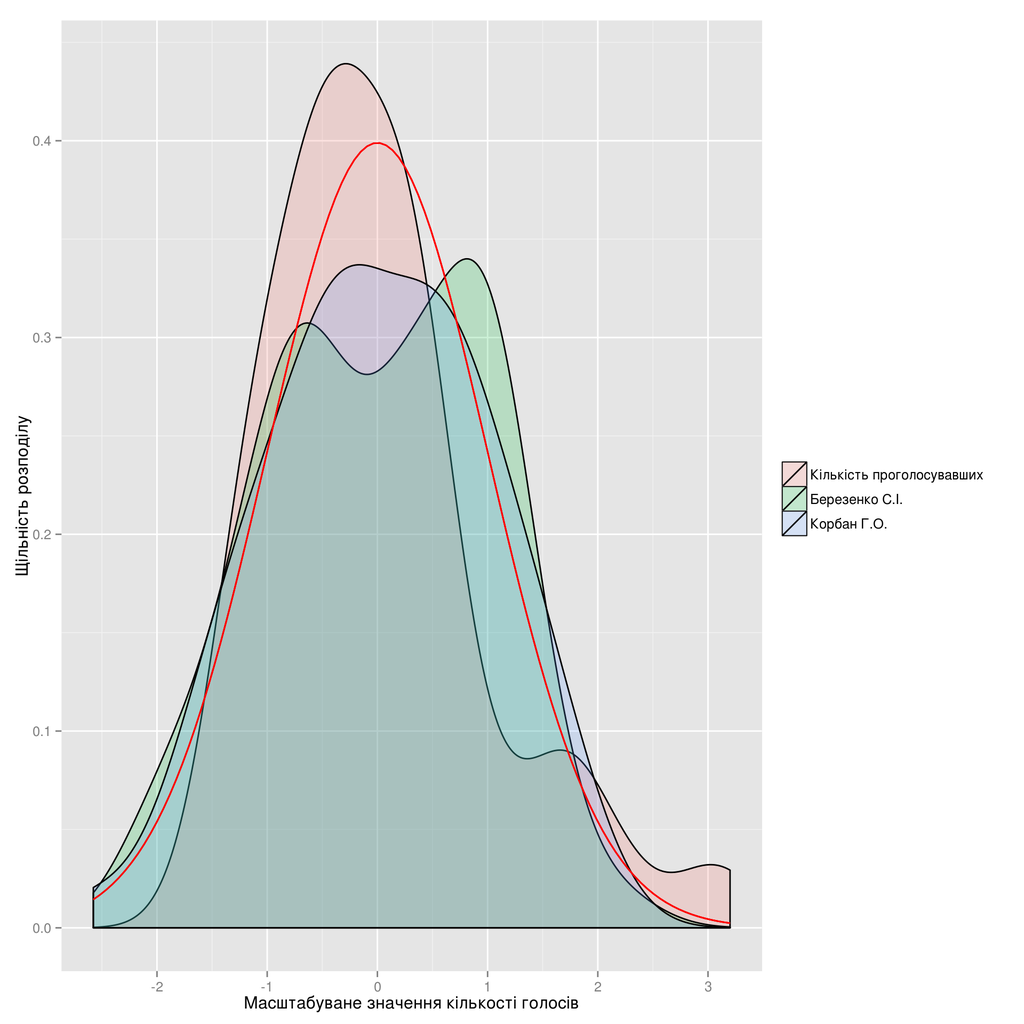

На данном рисунке нанесены нормированные распределения явки, а также голосов за Сергея Березнко и Геннадия Корбана. Красной линией отмечено нормальное распределение, которому должны соответствовать все остальные распределения в случае отсутствия аномалий.

В частности мы можем убедиться, что явка явно была форсирована - об этом свидетельсвтует выраженная правосторнняя асимметрия (пики в правом хвосте). Можем сравнить с аналогичными [графиками для Франции](http://journals.plos.org/plosone/article/figure/image?size=medium&id=info:doi/10.1371/journal.pone.0036289.g001).

Кроме этого мы можем наблюдать два интересных “горба” в распределении голосов за Сергея Березенко. Подобные пики в правой части графика, например, характерны для [сфальсифицированных выборов в России в 2011-2012 годах](http://www.ncbi.nlm.nih.gov/pmc/articles/PMC3478593/figure/fig02/).

Следовательно, на выборах происходило активное форсирование явки со стороны провластного кандидата.

### График кумулятивных распределений

Еще один тип визуального анализа предлагает построение графика зависимости кумуляты процента голосов от процента явки. При условии честного голосувания результат для каждой партии должен иметь “плато” в правой части графика.

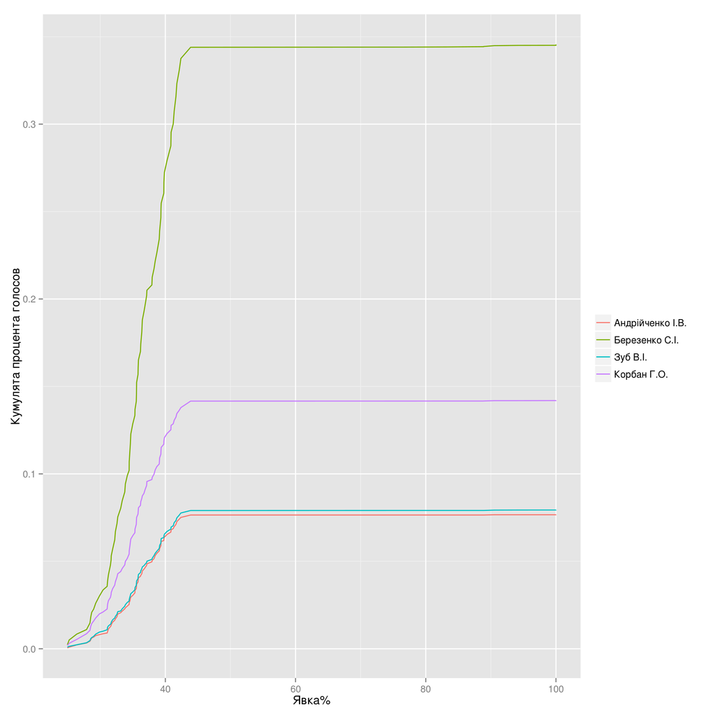

График позволяет нам убедиться в отсутствии избирательных участков с аномально высокой явкой и явным перекосом голосов в сторону одного из кандидатов.

## Анализ двумерных распределений

Одним из показателей фальсификации избирательного процесса является наличие сильной положительной корреляции между явкой и процентом голосов, отданных за кандидата. Нами был проведен анализ двумерных распределений. На изображениях ниже изображены точечные графики, на которых также изображена линия регрессии. Для случая, когда поддержка кандидата не должна зависеть от явки, данная линия должна быть приблизительно горизонтальной.

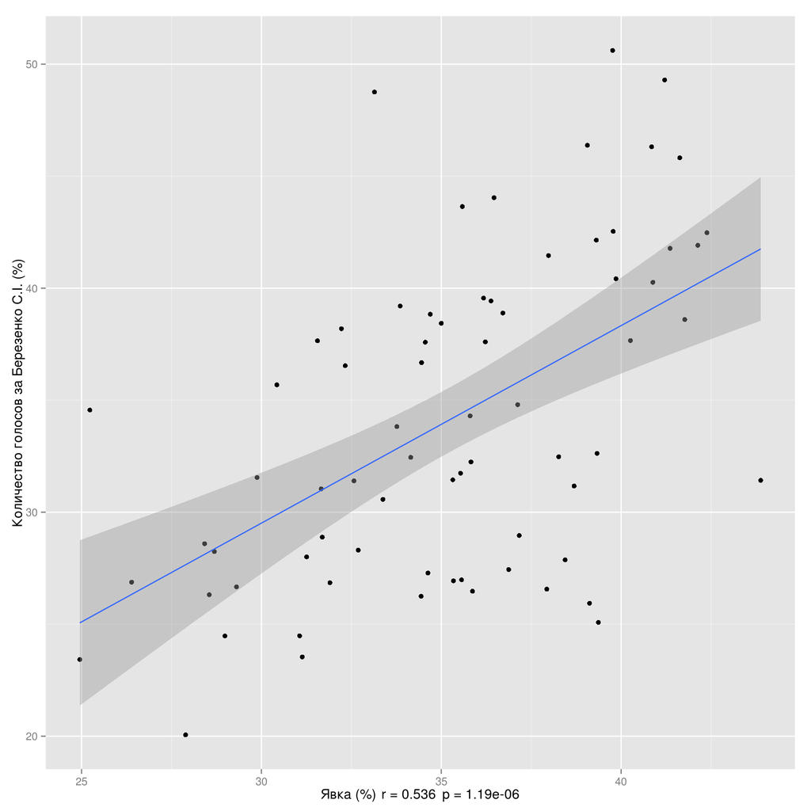

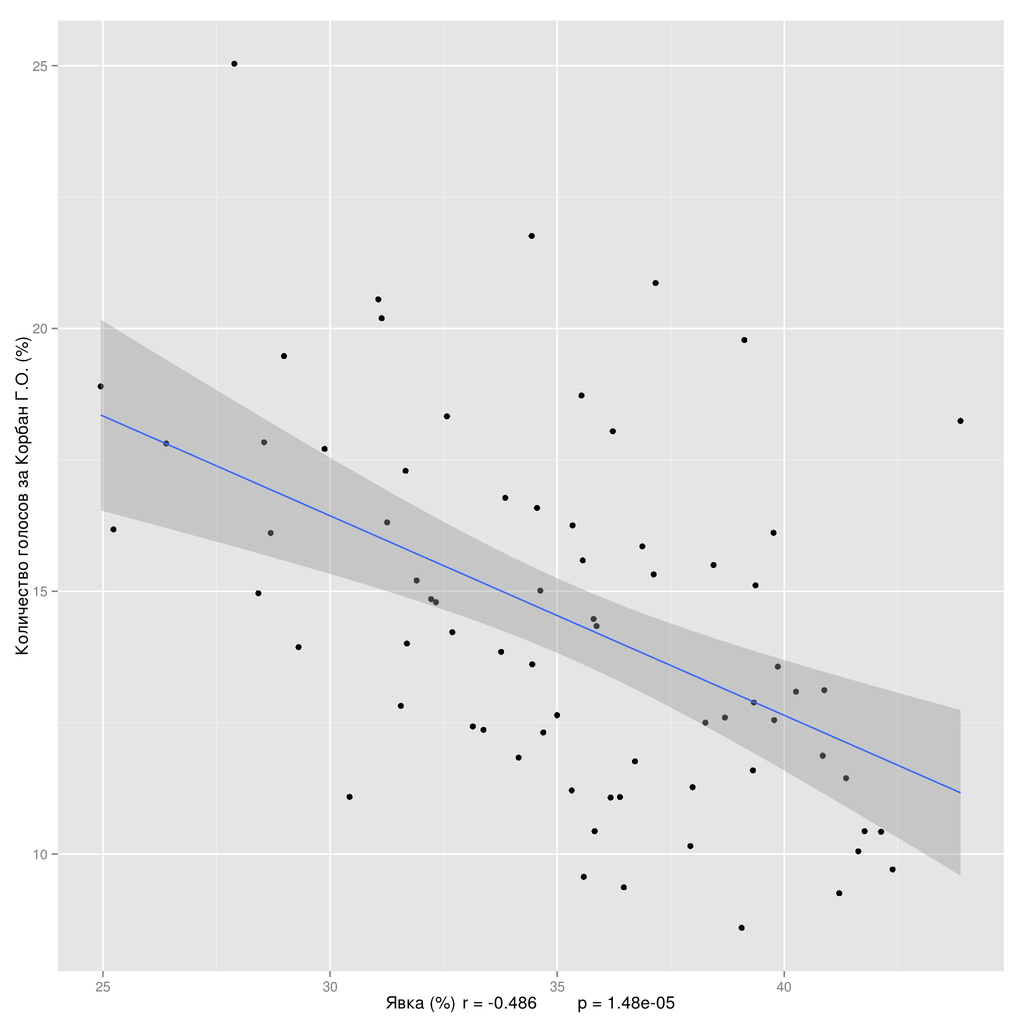

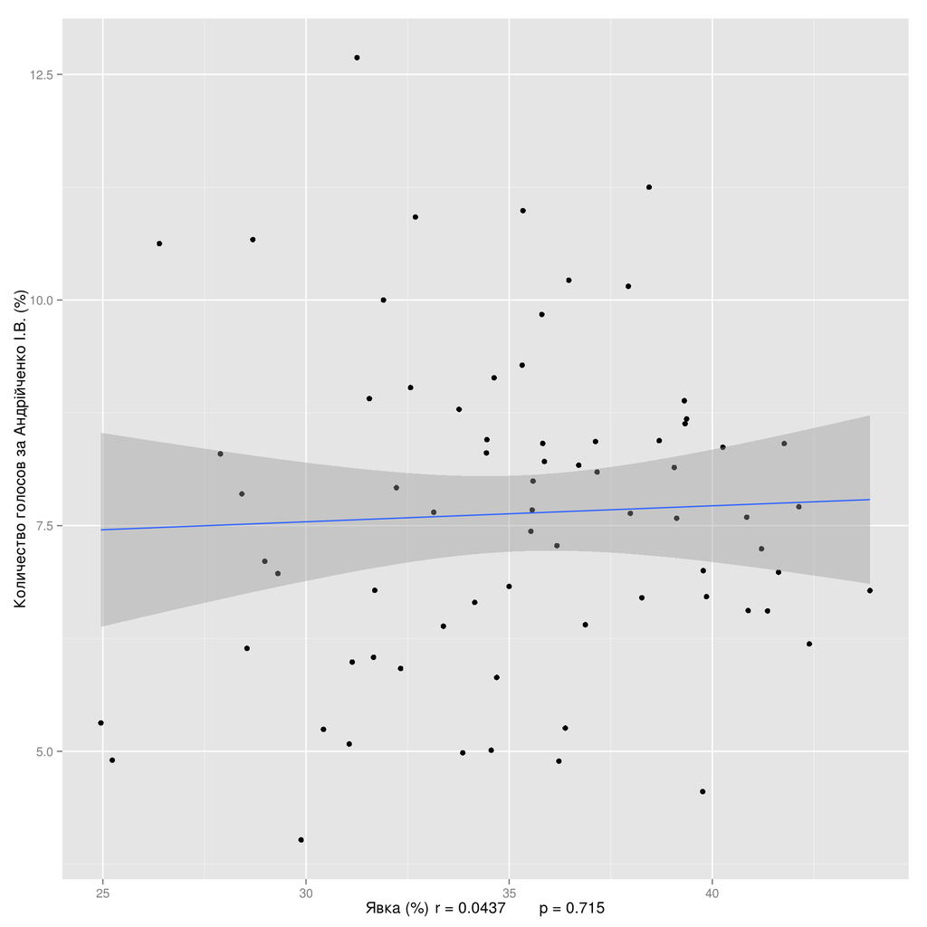

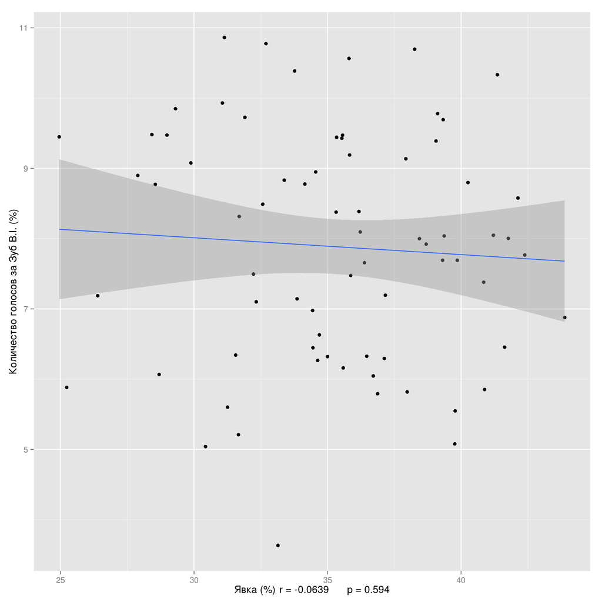

Полученные четыре графика показывают совершенно честные результаты для двух кандидатов - Игоря Андрейченко и Владимира Зуба. Ни для одного из них не наблюдается связь между явкой и количеством полученных голосов.

По-другому обстоит ситуация с Сергеем Березенко и Геннадием Корбаном. Мы видим четкую положительную связь между явкой и количеством голосов за Сергея Березенко и аналогиную отрицательную связь для голосов Геннадия Корбана. В некоторых случаях подобные связки могут указывать на воровство голосов кандидатом, у которого наблюдается положительная связь. Либо оба кандидата работают на одном электоральном поле и процент голосов за кандидата с отрицательной связью просто уменьшается ввиду того, что победивший кандидат привел значительно больше своих сторонников на ряд избирательных участков.

### Дополнительные факторы

Кроме выявленных выше общих закономерностей следует указать, что на выборах принимали участие технические кандидаты. В частности, барьер в 1% голосов приобрел Геннадий Карбан. Обычно, наличие сильной положительной связи может свидетельствовать о том, что технический кандидат успешно отобрал часть голосов.

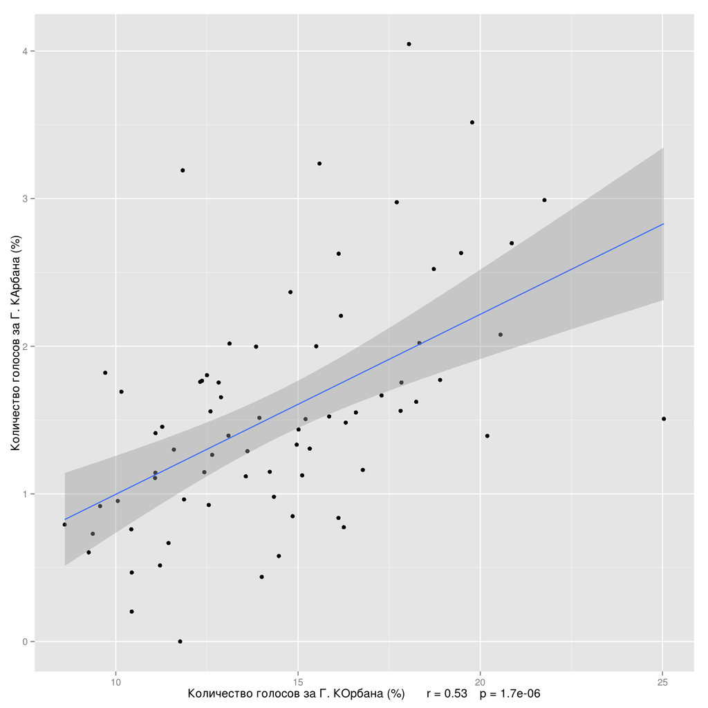

Другой интересный аспект - это то, что с Сергеем Березенко [достаточно тесно сотрудничал](http://pik.cn.ua/16003/berezenko-vibiv-dlya-dubilya-deputatskiy-mandat-shchob-toy-ne-balotuvavsya-u-205-okruzi/) народный депутат от партии ВО “Батьківщина” Валерий Дубиль и его протеже Андрей Дериземля.

Народный депутат Валерий Дубиль попал в Парламент в аккурат накануне выборов, удачно освободив место для кампании Сергея Березенко. Кроме этого, по слухам, народный избранник передал начинающему кампанию кандидату свою сетевую структуру, которая плотно сотрудничала с избирателями. Чтобы убедиться в этой гипотезе мы можем предположить, что эта же структура работала во время последних Внеочередных выборов народных депутатов в 2014 году. Следовательно между процентом голосов, отданными за Андрея Дериземлю в 2014 году, и процентом голосов за Сергея Березенко должна также быть положительная связь.

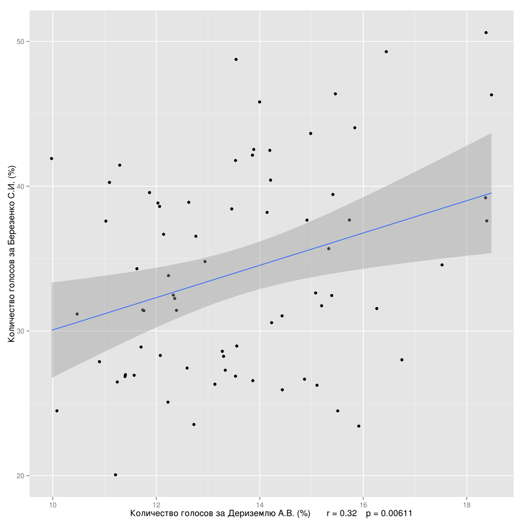

Наблюдаемая положительная связь подтверждает нашу гипотезу. При этом интересен тот факт, что связь между голосами Сергея Березенко, который выдвигался от Блока Петра Порошенко “Солидарность”, и голосам Валерия Кулича, который выдвигался в 2014 году от Блока Петра Порошенко, не наблюдается, что предположительно может говорить о некотором расколе между командами на местном уровне.

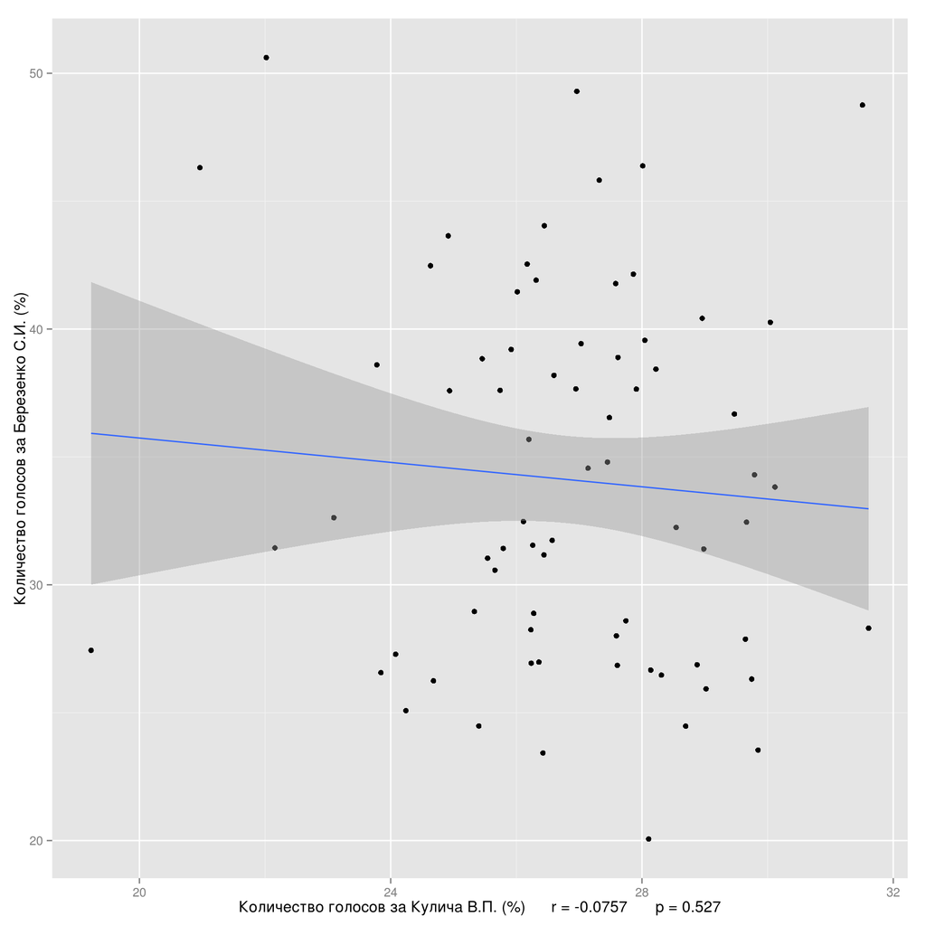

# Карта избирательных участков

Последним методом, который мы применим, чтобы убедиться в наличии как минимум “серых” технологий со стороны Сергея Березенко, будет картирование избирательных участков. Для решения данной задачи мы геокодировали адреса помещений избирательных комиссий и нанесли их на карту. Размер круга соответствует величине избирательного участка, а цвет - проценту голосов, который набрал кандидат. Для того, чтобы помещения комиссий, находящиеся по одному и тому же адресу не накладывались друг на друга, в их координаты был добавлен небольшой “шум”.

Предлагаю рассмотреть две карты: одну для результатов Сергея Березенко и одну для результатов Геннадия Корбана.

[interactive chart not shown]

Мы можем четко наблюдать территориальную неравномерность полученных Сергеем Березенко голосов. Причем указанная равномерность явно является неслучайной - наибольшее количество голосов кандидат получил в восточной части округа и меньше - в западной. Отметим, что аналогичное неравномерное количество голосов можно было наблюдать в свое время по [223 округу, где баллотировался Виктор Пилипишин](http://pro-media.com.ua/ru/blogs/intrigi-i-zagadki-vyborov-na-223-okruge).

В то же время результаты Геннадия Корбана явно не имеют некой специфической территориальной зависимости.

[interactive chart not shown]

# Заключение

По имеющейся информации у Геннадия Корбана была одна из лучших команд по разрешению юридических вопросов и кандидат был намерен в случае недостатка голосов перевести политическую борьбу в судебную плоскость. Ко дню голосования на участках ожидалось множество провокаций, но большинство наблюдателей и представителей правоохранительных органов констатировали, что серьезных нарушений не было. Проведенный анализ показывает, что победа Сергеем Березенко, скорее всего, была получена без непосредственных фальсификаций на избирательных участках. Но в то же время львную долю этой победы обеспечили структурированные сети избирателей и открытым остается вопрос мотивации данных граждан. Была ли столь убедительной агитационная работа кандидата или совершался подкуп каждый ответи для себя сам.

# Ссылки

1. Сайт Центральної виборчої комісії. URL: [http://cvk.gov.ua/]
2. Joe Cheng and Yihui Xie (2015). leaflet: Create Interactive Web Maps with the JavaScript ‘Leaflet’ Library. R package version 1.0.0. http://CRAN.R-project.org/package=leaflet
3. H. Wickham. ggplot2: elegant graphics for data analysis. Springer New York, 2009.
4. Hadley Wickham (2014). scales: Scale functions for graphics.. R package version 0.2.4. [http://CRAN.R-project.org/package=scales]
5. Hadley Wickham and Romain Francois (2015). dplyr: A Grammar of Data Manipulation. R package version 0.4.1. [http://CRAN.R-project.org/package=dplyr]
6. R Core Team (2014). R: A language and environment for statistical computing. R Foundation for Statistical Computing, Vienna, Austria. URL [http://www.R-project.org/]